# Bernard_Asante_Missing_Data_Imputation

Bernard Asante

2025-02-01

# **Reading the dataset**

```r
path = "T:\\Desktop\\USASK\\Year One\\WINTER\\Data Science\\Data\\can_path_data.csv"

data <- read_csv(path)
#data %>%
  #glimpse()  # Output is too long.
```

## Broad overview of missing data in dataset

```r
miss_var_summary(data) #The function miss_var_summary(data) from the naniar package summarizes missing data by variable. It returns a table showing the number and percentage of missing values for each column in the dataset. This helps identify which variables are most affected by missingness.
```

```
## # A tibble: 440 × 3
##    variable                       n_miss pct_miss
##    <chr>                           <int>    <num>
##  1 DIS_MH_BIPOLAR_EVER             41171    100.
##  2 DIS_GEN_DS_EVER                 41143     99.9
##  3 DIS_GEN_AIS_EVER                41143     99.9
##  4 DIS_GEN_HEMOPHILIA_EVER         41143     99.9
##  5 DIS_GEN_KS_EVER                 41143     99.9
##  6 DIS_GEN_TS_EVER                 41143     99.9
##  7 DIS_GEN_CAH_EVER                41141     99.9
##  8 DIS_GEN_CF_EVER                 41138     99.9
##  9 DIS_GEN_THALASSEMIA_EVER        41107     99.8
## 10 DIS_CARDIO_PREM_HD_FEMALE_EVER  41081     99.7
## # ℹ 430 more rows
```

It can be observed some variables has more than 99 % missing values, at least from the first 10 rows. These variables are probably missing not at random(MNAR). For efficiency seek, I have decided to retain only variables with less that 20% missing values.

## Missing data overview

```r
data_pct <- data %>%
          select(where(~sum(is.na(.x))/length(.x) < 0.20))  #This code filters the dataset data to retain only variables with less than 20% missing values.
missing_table <- miss_var_summary(data_pct) #It then generates a summary table of missing values for the filtered dataset using miss_var_summary().

missing_table # missing_table is the variable showing how much missing data remains in each retained variable.
```

```
## # A tibble: 199 × 3
##    variable               n_miss pct_miss
##    <chr>                   <int>    <num>
##  1 DIS_STROKE_FAM_EVER      8110     19.7
##  2 DIS_ARTHRITIS_FAM_EVER   7955     19.3
##  3 HS_SIG_EVER              7767     18.9
##  4 DIS_CANCER_F_EVER        7632     18.5
##  5 DIS_MI_FAM_EVER          7526     18.3
##  6 HS_SIG_LAST              7494     18.2
##  7 HS_MMG_LAST              7377     17.9
##  8 DIS_LC_AGE               7354     17.9
##  9 DIS_DIAB_FAM_EVER        7343     17.8
## 10 DIS_CANCER_M_EVER        7086     17.2
## # ℹ 189 more rows
```

```r
# Selecting 7 columns randomly from the dataset due to high computation power required for the entire dataset
health_data <- data %>%

  select(ID,HS_GEN_HEALTH,NUT_VEG_QTY, NUT_FRUITS_QTY,PA_TOTAL_SHORT,DIS_ASTHMA_EVER,DIS_DIAB_EVER)

write.csv(health_data, "health_data.csv",row.names = FALSE)
```

# **Sliced dataset[health_data]**

```r
health_data <- read_csv("health_data.csv")
health_data %>%
  glimpse()   #The glimpse() function from the dplyr package provides a quick, structured overview of the health_data dataset. It shows the number of rows and columns, as well as the type and a preview of values in each column. This helps understand the structure and content of the dataset at a glance.
```

```
## Rows: 41,187
## Columns: 7
## $ ID              <chr> "SYN_58621", "SYN_58622", "SYN_58623", "SYN_58624", "S…
## $ HS_GEN_HEALTH   <dbl> 3, 4, 3, 4, 3, 5, 5, 3, 3, 4, 4, 4, 4, 5, 5, 3, 4, NA,…
## $ NUT_VEG_QTY     <dbl> 3, 0, 5, 1, 2, 5, 3, 5, 8, 1, 1, 3, 2, 2, 3, 1, 4, NA,…
## $ NUT_FRUITS_QTY  <dbl> 1, 0, 3, 3, 3, 5, 3, 2, 5, 0, 1, 5, 3, 1, 2, 1, 3, NA,…
## $ PA_TOTAL_SHORT  <dbl> 3564.0, 0.0, NA, 594.0, NA, NA, 2118.0, 297.0, NA, 240…
## $ DIS_ASTHMA_EVER <dbl> 0, 0, 2, 0, 1, 2, 0, NA, 0, 0, NA, 0, 0, 0, 0, 0, 0, 0…
## $ DIS_DIAB_EVER   <dbl> 0, 0, 2, NA, 2, 2, 0, 0, 0, 0, 0, 0, 0, 0, 0, 0, 0, 0,…
```

This is to give an overview of the new dataset (health_data.csv) displaying number of row (41187) and columns(7)

```r
health_data  %>%
  head()  # Displaying the first 6 rows of the dataet
```

```
## # A tibble: 6 × 7
##   ID     HS_GEN_HEALTH NUT_VEG_QTY NUT_FRUITS_QTY PA_TOTAL_SHORT DIS_ASTHMA_EVER
##   <chr>          <dbl>       <dbl>          <dbl>          <dbl>           <dbl>
## 1 SYN_5…             3           3              1           3564               0
## 2 SYN_5…             4           0              0              0               0
## 3 SYN_5…             3           5              3             NA               2
## 4 SYN_5…             4           1              3            594               0
## 5 SYN_5…             3           2              3             NA               1
## 6 SYN_5…             5           5              5             NA               2
## # ℹ 1 more variable: DIS_DIAB_EVER <dbl>
```

```r
health_data %>%
  tail()  # Displaying the first 6 rows of the dataet
```

```
## # A tibble: 6 × 7
##   ID     HS_GEN_HEALTH NUT_VEG_QTY NUT_FRUITS_QTY PA_TOTAL_SHORT DIS_ASTHMA_EVER
##   <chr>          <dbl>       <dbl>          <dbl>          <dbl>           <dbl>
## 1 SYN_5…             4           5              2            NA                0
## 2 SYN_5…             4           1              1           819                0
## 3 SYN_5…             5           1              1           753                0
## 4 SYN_5…             3           2              1             0                0
## 5 SYN_5…             3           2              3          1860.               0
## 6 SYN_5…             2           4              2          2133                0
## # ℹ 1 more variable: DIS_DIAB_EVER <dbl>
```

```r
health_data %>%
  summary() # The summary() function provides basic descriptive statistics for each variable in the health_data dataset. For numeric variables, it returns the minimum, 1st quartile, median, mean, 3rd quartile, and maximum values, along with the count of missing values (NA's). This offers a statistical snapshot of the dataset’s distribution and data quality.
```

```
##       ID            HS_GEN_HEALTH    NUT_VEG_QTY     NUT_FRUITS_QTY
##  Length:41187       Min.   :1.000   Min.   : 0.000   Min.   : 0.000
##  Class :character   1st Qu.:3.000   1st Qu.: 2.000   1st Qu.: 1.000
##  Mode  :character   Median :4.000   Median : 2.000   Median : 2.000
##                     Mean   :3.638   Mean   : 2.672   Mean   : 2.132
##                     3rd Qu.:4.000   3rd Qu.: 3.000   3rd Qu.: 3.000
##                     Max.   :5.000   Max.   :35.000   Max.   :25.000
##                     NA's   :672     NA's   :2549     NA's   :2426
##  PA_TOTAL_SHORT  DIS_ASTHMA_EVER  DIS_DIAB_EVER
##  Min.   :    0   Min.   :0.0000   Min.   :0.0000
##  1st Qu.:  600   1st Qu.:0.0000   1st Qu.:0.0000
##  Median : 1782   Median :0.0000   Median :0.0000
##  Mean   : 2574   Mean   :0.2039   Mean   :0.1402
##  3rd Qu.: 3732   3rd Qu.:0.0000   3rd Qu.:0.0000
##  Max.   :19278   Max.   :2.0000   Max.   :2.0000
##  NA's   :6763    NA's   :1228     NA's   :1340
```

It can be observed that each variable has a missing data (NA’s). This will be explained further in the next code

# **Missing Data Exploration**

```r
missing_columns <- health_data %>%
  summarise_all(~sum(is.na(.))) # This code calculates the total number of missing values in each column of the health_data dataset. It uses summarise_all() with a function that counts NAs, returning a one-row summary where each column shows its respective missing count. The result is stored in missing_columns.


missing_columns
```

```
## # A tibble: 1 × 7
##      ID HS_GEN_HEALTH NUT_VEG_QTY NUT_FRUITS_QTY PA_TOTAL_SHORT DIS_ASTHMA_EVER
##   <int>         <int>       <int>          <int>          <int>           <int>
## 1     0           672        2549           2426           6763            1228
## # ℹ 1 more variable: DIS_DIAB_EVER <int>
```

Now that I know the missing values for each columns, I want to visualize them on a simple bar graph to see the order frequency of missing values for each column

## Visualization of missing data per columns

```r
missing_columns_long <- missing_columns %>%
  pivot_longer(cols = HS_GEN_HEALTH:DIS_DIAB_EVER, names_to = "columns", values_to = "counts") #This code reshapes the missing_columns summary into a long format using pivot_longer(), converting each column name and its missing value count into row entries.

missing_columns_long     #The new dataframe missing_columns_long contains two columns: columns (variable names) and counts (number of missing values). This format is ideal for plotting
```

```
## # A tibble: 6 × 3
##      ID columns         counts
##   <int> <chr>            <int>
## 1     0 HS_GEN_HEALTH      672
## 2     0 NUT_VEG_QTY       2549
## 3     0 NUT_FRUITS_QTY    2426
## 4     0 PA_TOTAL_SHORT    6763
## 5     0 DIS_ASTHMA_EVER   1228
## 6     0 DIS_DIAB_EVER     1340
```

Here we see columns and counts(which represents the number of missing values in each variable)

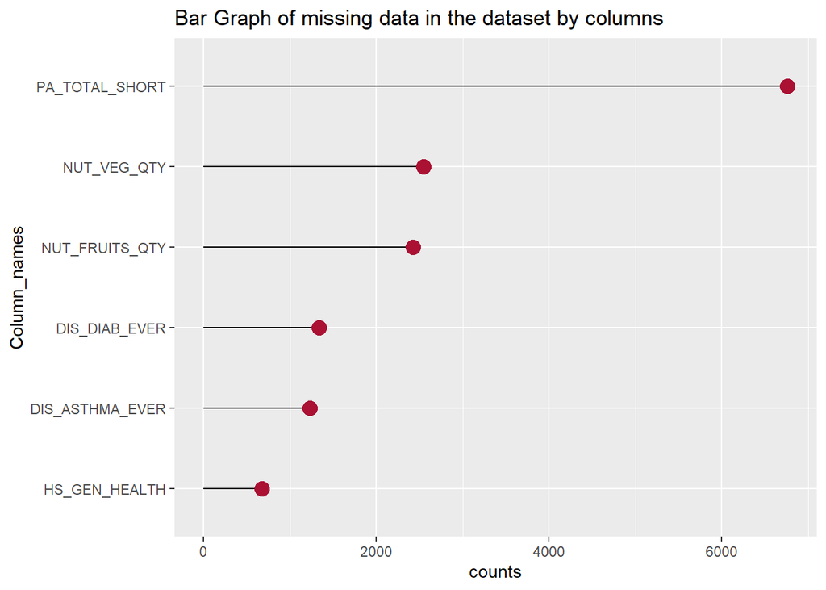

```r
missing_plot <- missing_columns_long %>%
  ggplot(aes(x = reorder(columns,counts), y = counts))+
  geom_segment(aes(x = reorder(columns,counts), yend = counts, xend = reorder(columns,counts), y =0))+
  geom_point(size = 4, colour = "#a13")+
  coord_flip()+
  labs(title = "Bar Graph of missing data in the dataset by columns", x = "Column_names")  # This code uses ggplot2 to create a horizontal bar plot showing the number of missing values per column in the dataset. It uses geom_segment() to draw the bars and geom_point() to emphasize each missing count. The columns are reordered by the number of missing values for better readability, and coord_flip() is used to display the bars horizontally.

missing_plot
```

From the graph, it can be seen that PA-TOTAL_SHORT has the highest missing data around 7000 where as HS_GEN_HEALTH has the least values less that 1000. The next step is to calculate for the percentage of missing data in each column usinng the miss_var_summary

## Percentage of the missing data

```r
missing_data <- miss_var_summary(health_data) # This code uses miss_var_summary() to generate a summary of missing values for each variable in health_data, including both count and percentage of missing values.

missing_data %>%
  head(5) # The head(5) function then displays the top 5 variables with the highest missing value counts.
```

```
## # A tibble: 5 × 3
##   variable        n_miss pct_miss
##   <chr>            <int>    <num>
## 1 PA_TOTAL_SHORT    6763    16.4
## 2 NUT_VEG_QTY       2549     6.19
## 3 NUT_FRUITS_QTY    2426     5.89
## 4 DIS_DIAB_EVER     1340     3.25
## 5 DIS_ASTHMA_EVER   1228     2.98
```

I know Physical activity variable has the highest missing values of 16.4% this is evident from the bar graph above.

For other variables, the percentage of missing data is rarely a problem , Nut_veg_qty(6.19%), nut_fruits_qty(5.89%), Dis_asthma_Ever(2.98%) and Hs_Gen_health(1.63%). This is likely to make the data Missing Completely at Random(MCAR). However, it is hard to say for Pa_total_short which has a missing data 0f 16.4%, probably Missing at Random(MAR). These are mere assumptions and need to be analyzed further.

The visdat package was used to make some visualization to better understand the pattern of missing data in the dataset.

# **Visdat**

## vis_dat()

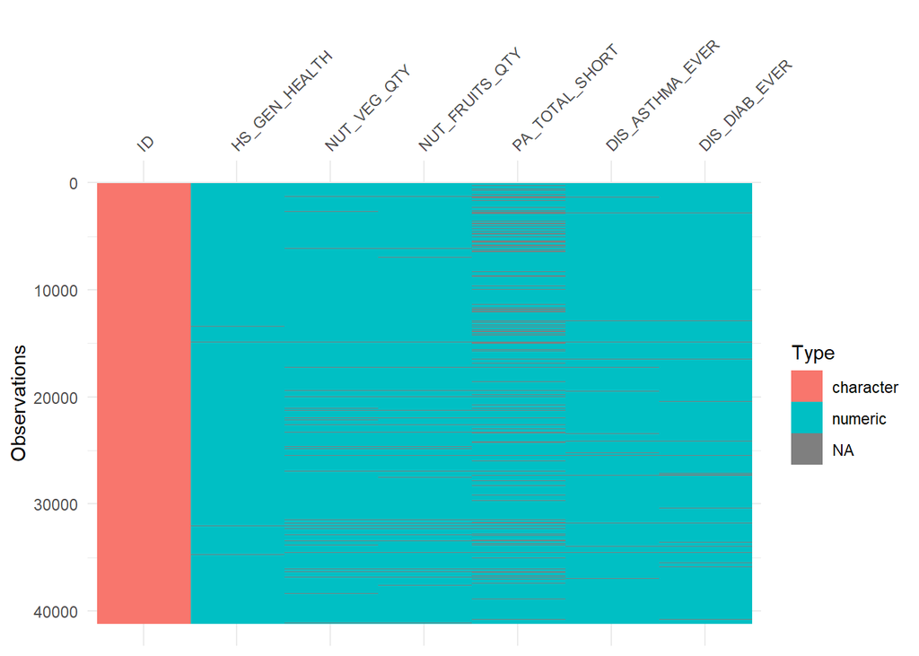

```r
data_col_type <- vis_dat(health_data)  # The vis_dat(health_data) function from the visdat package creates a visualization showing the data type and missingness for each variable in the dataset. Each cell in the plot represents a data value, color-coded by type ( numeric, character, missing as seen in the plot).

data_col_type # The output data_col_type is a ggplot object displaying this structure.
```

The gray color represents missing values in the dataset. It can be seen that ID has no missing values. Few missing values was seen with some variables which corresponds to the percentages above and the bar graph. we can see a lot of missing data in the Pa_total_short column.

## Vis_miss()

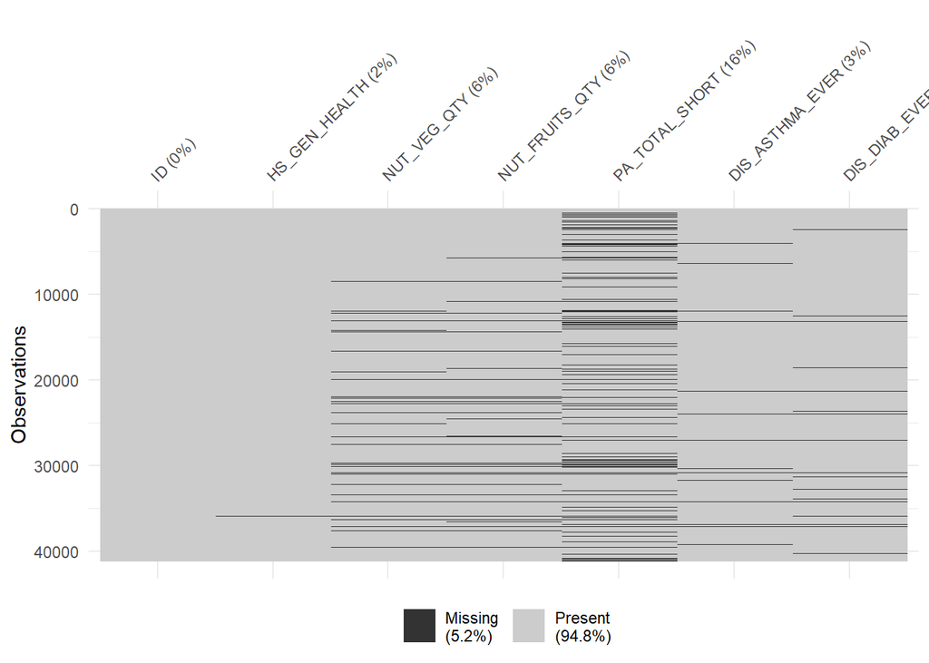

```r
vis_miss(health_data) # This code use the vis_miss() from the visdt package to display the percentage of missing data in each variable.
```

This is to display only the missing values. The mising percentage can be seen against the names of each variable on the graph. This is same to the one observed using miss_var_summary from naniar package.

## vis_cor()

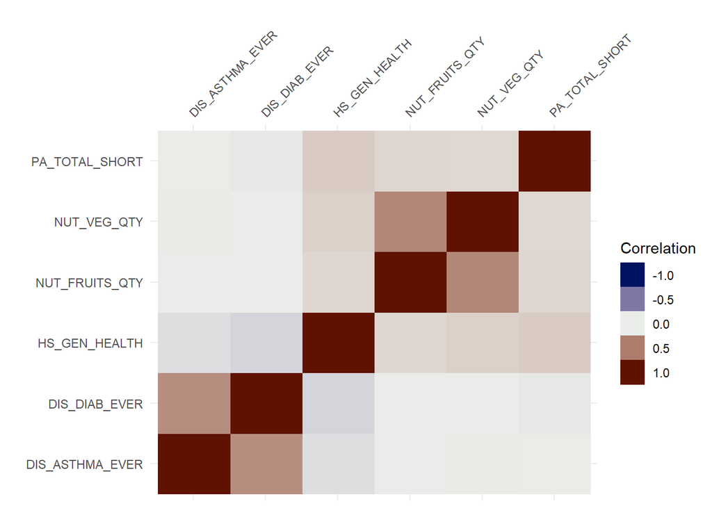

```r
health_data_numeric <- health_data %>%
  select(where(is.numeric)) # Selecting only numeric variables becuase the  vis_cor() function works on only numerical variables

vis_cor(health_data_numeric) # The function computes pairwise correlations and produces a heatmap that visually represents the strength and direction of relationships between numeric variables. Correlation values range from -1 (perfect negative) to +1 (perfect positive) with colour bar explaining the degree of correlation.
```

This heatmap is to display the correlation between the numeric variables in the dataset. There were moderate correlation observed between some of the variables; veg quantity and fruits quantity. similar observation is seen between diabetes ever and asthma ever. From theory, missing data in strongly correlated variables can be imputed using values from the other( except MNAR). But in this analysis, my interest is with Physical activity total which has mild correlation with the nutritional and diseases variables and mild - moderate correlation with hs_gen_health. ## gg_miss_upset

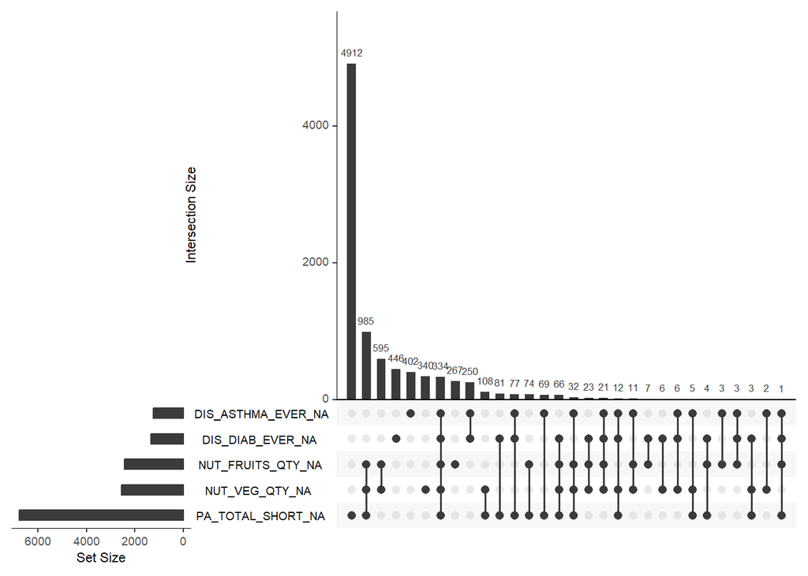

```r
gg_miss_upset(health_data)  # The gg_miss_upset(health_data) function from the naniar package creates an UpSet plot that visualizes combinations of missing values across multiple variables. It shows how many observations have missing data in specific columns and in what combinations. This is especially useful when dealing with overlapping missingness in multiple variables.
```

From the gg-miss_upset plot above, we can observe a connection between missing data points in physical activity and the nutritional(NUT) variables, Physical activity NA is connected to all the variables at the intersection size of 334.

I want to run further test to assess if the missingness in PA_TOTAL_SHORT is dependent on observed values in the other variables.

# **Determining the type of missingness**

## Little MCAR test from naniar

```r
mcar_test(health_data) # The mcar_test(health_data) function from the naniar package performs Little’s MCAR (Missing Completely At Random) test on the dataset. It statistically tests whether the missing data pattern is completely random or not. The output includes a chi-square statistic, degrees of freedom, and a p-value.
```

```
## # A tibble: 1 × 4
##   statistic    df p.value missing.patterns
##       <dbl> <dbl>   <dbl>            <int>
## 1     8290.   229       0               58
```

The mcar test has the null hypothesis: The missing data is completerly at random(MCAR). Alternative hypothesis states that, missing data is not completely at random that is, it can be MAR or MNAR.

The test had a pvalue less than 0.001. This is a strong evidence to reject the null hypothesis and conclude that the data is not missing completely at random.

I want to see if missingness in pa_total is MAR or MNAR using logistic regression to see how the various variables predicts the “NA” variables in pa_total_short. Logistic regression is used here because the missing data “NA” is not continuous but rather “TRUE” or “FALSE” as can be seen in *missing_pa_total*.

## Logistic Regression Model

```r
missing_Pa_total <- is.na(health_data$PA_TOTAL_SHORT) %>%
  head() #This code  is to give a logical output(TRUE or FAlSe) is there is missing value in PA_TOTAL_SHORT

print(missing_Pa_total)  # This displays the columns values as logical; TRUE and FALSE making binomial logistic regression appropriate
```

```
## [1] FALSE FALSE  TRUE FALSE  TRUE  TRUE
```

```r
glm(is.na(PA_TOTAL_SHORT) ~ HS_GEN_HEALTH + NUT_FRUITS_QTY + DIS_ASTHMA_EVER + DIS_DIAB_EVER,
    data = health_data,
    family = binomial) %>%
  summary()   # This code fits a binomial logistic regression model to predict whether the variable PA_TOTAL_SHORT is missing (TRUE) or not (FALSE). The predictors used are HS_GEN_HEALTH, NUT_FRUITS_QTY, DIS_ASTHMA_EVER, and DIS_DIAB_EVER. The model estimates the likelihood of missingness in PA_TOTAL_SHORT based on these other health-related variables.
```

```
##
## Call:
## glm(formula = is.na(PA_TOTAL_SHORT) ~ HS_GEN_HEALTH + NUT_FRUITS_QTY +
##     DIS_ASTHMA_EVER + DIS_DIAB_EVER, family = binomial, data = health_data)
##
## Coefficients:
##                 Estimate Std. Error z value Pr(>|z|)
## (Intercept)     -3.16688    0.07425 -42.652  < 2e-16 ***
## HS_GEN_HEALTH    0.18665    0.01838  10.153  < 2e-16 ***
## NUT_FRUITS_QTY   0.04964    0.01123   4.421 9.84e-06 ***
## DIS_ASTHMA_EVER  0.69945    0.03217  21.739  < 2e-16 ***
## DIS_DIAB_EVER    1.42437    0.03336  42.703  < 2e-16 ***
## ---
## Signif. codes:  0 '***' 0.001 '**' 0.01 '*' 0.05 '.' 0.1 ' ' 1
##
## (Dispersion parameter for binomial family taken to be 1)
##
##     Null deviance: 29271  on 37251  degrees of freedom
## Residual deviance: 25177  on 37247  degrees of freedom
##   (3935 observations deleted due to missingness)
## AIC: 25187
##
## Number of Fisher Scoring iterations: 5
```

It can be observed that all the variables has a pvalue < 0.001 indicating they are significant predictors of the missingness in the pa_total_short variable. Again this is an assumption from the model and can not be proven with high certainty

## Geom_miss_plot

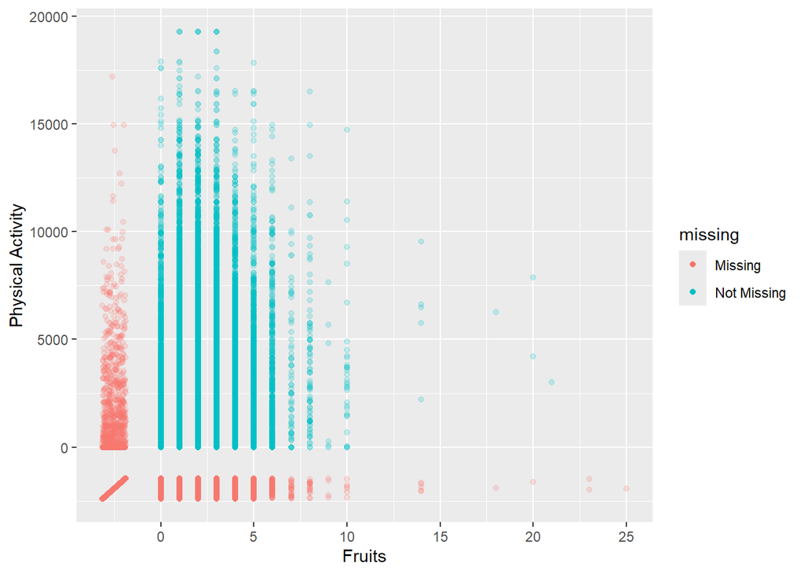

```r
scatter_plot_miss <- ggplot(health_data, aes(x = NUT_FRUITS_QTY, y = PA_TOTAL_SHORT)) +
                  geom_miss_point(alpha = 0.2) +
                  labs(x = "Fruits", y = "Physical Activity")
plot(scatter_plot_miss)  # This code creates a scatter plot using ggplot2 with geom_miss_point() from the naniar package, which plots data points while also highlighting missing values. The x-axis represents NUT_FRUITS_QTY and the y-axis PA_TOTAL_SHORT, with semi-transparent (alpha = 0.2) points. Missing values in either variable are marked distinctly with default "orange" colour.
```

It can be observed that missing decreases as fruit intake increases above 8. A lot of missing data was also between 0 to 5000 minutes of exercise, however, missingness reduces above 5000 minutes upwards.

# **Shadow matrix**

```r
data_shadow <- health_data %>%
  bind_shadow()  # The bind_shadow() function from the naniar package appends shadow columns to the original health_data dataset. For every original variable, it creates a new column with the _NA suffix, indicating whether each value is missing (NA) or not (!NA). The result, data_shadow, enables tracking and modeling of missingness directly.

data_shadow %>%
  head() # This displays the first 6 rows of the data_shadow variable
```

```
## # A tibble: 6 × 14
##   ID     HS_GEN_HEALTH NUT_VEG_QTY NUT_FRUITS_QTY PA_TOTAL_SHORT DIS_ASTHMA_EVER
##   <chr>          <dbl>       <dbl>          <dbl>          <dbl>           <dbl>
## 1 SYN_5…             3           3              1           3564               0
## 2 SYN_5…             4           0              0              0               0
## 3 SYN_5…             3           5              3             NA               2
## 4 SYN_5…             4           1              3            594               0
## 5 SYN_5…             3           2              3             NA               1
## 6 SYN_5…             5           5              5             NA               2
## # ℹ 8 more variables: DIS_DIAB_EVER <dbl>, ID_NA <fct>, HS_GEN_HEALTH_NA <fct>,
## #   NUT_VEG_QTY_NA <fct>, NUT_FRUITS_QTY_NA <fct>, PA_TOTAL_SHORT_NA <fct>,
## #   DIS_ASTHMA_EVER_NA <fct>, DIS_DIAB_EVER_NA <fct>
```

The data shadow add an indicator matrix to the dataset to display is a value is missing(NA) or not missing(!NA)

# **Data Imputation**

## Summarizing missing data

```r
summary(health_data$PA_TOTAL_SHORT) # The  line  of code provides a five-number summary and counts of missing values in PA_TOTAL_SHORT.
```

```
##    Min. 1st Qu.  Median    Mean 3rd Qu.    Max.    NA's
##       0     600    1782    2574    3732   19278    6763
```

```r
health_data %>% summarise(
  n_distinct = n_distinct(PA_TOTAL_SHORT),
  mean_data = mean(PA_TOTAL_SHORT,na.rm = TRUE),
  n_miss = sum(is.na(PA_TOTAL_SHORT)),
  median_data = median(PA_TOTAL_SHORT, na.rm = TRUE)
)  # This code uses summarise() to calculate specific statistics: number of unique values (n_distinct), mean, median, and total number of missing entries. Missing values are excluded (na.rm = TRUE) from mean and median calculations.
```

```
## # A tibble: 1 × 4
##   n_distinct mean_data n_miss median_data
##        <int>     <dbl>  <int>       <dbl>
## 1       3421     2574.   6763        1782
```

This data summary includes unique values (n_distinct = 3421), mean (mean_data = 2574.089), missing values (n_miss = 6763), and median (median_data = 1782).

# **Mean Imputation**

```r
data_shadow$pa_not_imputed <- data_shadow$PA_TOTAL_SHORT  # Adding a column called pa_not_imputed to maintain pa_total values after imputation

data_shadow <- impute_mean_at(data_shadow, .vars = vars(PA_TOTAL_SHORT))  # This code uses the impute_mean_at() function to fill in missing values in the PA_TOTAL_SHORT variable with its mean value. It applies the imputation to the data_shadow dataset, which includes shadow columns tracking missingness. This is a simple, fast method suitable when data is assumed to be Missing Completely At Random (MCAR).


data_shadow %>%
  head()
```

```
## # A tibble: 6 × 15
##   ID     HS_GEN_HEALTH NUT_VEG_QTY NUT_FRUITS_QTY PA_TOTAL_SHORT DIS_ASTHMA_EVER
##   <chr>          <dbl>       <dbl>          <dbl>          <dbl>           <dbl>
## 1 SYN_5…             3           3              1          3564                0
## 2 SYN_5…             4           0              0             0                0
## 3 SYN_5…             3           5              3          2574.               2
## 4 SYN_5…             4           1              3           594                0
## 5 SYN_5…             3           2              3          2574.               1
## 6 SYN_5…             5           5              5          2574.               2
## # ℹ 9 more variables: DIS_DIAB_EVER <dbl>, ID_NA <fct>, HS_GEN_HEALTH_NA <fct>,
## #   NUT_VEG_QTY_NA <fct>, NUT_FRUITS_QTY_NA <fct>, PA_TOTAL_SHORT_NA <fct>,
## #   DIS_ASTHMA_EVER_NA <fct>, DIS_DIAB_EVER_NA <fct>, pa_not_imputed <dbl>
```

This displays the first six(6) rows of the mean imputed physical activity total.

## Visualizing Density Plots

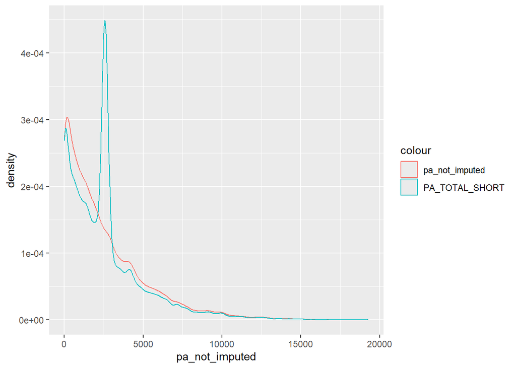

```r
density_mean_imp <- ggplot(data_shadow) +
                geom_density(aes(pa_not_imputed, colour= "pa_not_imputed")) +
                geom_density(aes(PA_TOTAL_SHORT, colour= "PA_TOTAL_SHORT"))
plot(density_mean_imp)  # This ggplot2 code creates a density plot to compare the distribution of the original (non-imputed) PA_TOTAL_SHORT values (pa_not_imputed) with the mean-imputed values in PA_TOTAL_SHORT. Different colors are used to distinguish the two distributions, providing a visual comparison of their shapes.
```

## Descriptive comparison of imputed and non imputed dataset

```r
median_pa_not_imputed <- median(data_shadow$pa_not_imputed,na.rm = TRUE)

median_pa_not_imputed
```

```
## [1] 1782
```

```r
median_pa_imputed <- median(data_shadow$PA_TOTAL_SHORT) # "NA" has been removed so need not to add na.rm
median_pa_imputed
```

```
## [1] 2379
```

It can be observed that the median for non imputed pa short column is 1782 and increased to 2379 after mean imputation.

## Boxplot of PA_TOTAL_SHORT before mean_imputation

The code below is to measure side by side the distribution of the variables after and before imputation using a boxplot.

```r
Non_imputed_pa <- ggplot(data_shadow, aes(x  = pa_not_imputed)) +
         geom_boxplot(outlier.shape = NA) +  # Avoid extreme outliers hiding the boxplot
         labs(title = " Total Physical Activity Before Mean Imputation",
              subtitle = "Median around 1700 ",
              y = "Total Physical Activity")+
         coord_flip()+
         theme_minimal()
```

## Boxplot of PA_TOTAL_SHORT after mean_imputation

```r
imputed_pa <- ggplot(data_shadow, aes(x  = PA_TOTAL_SHORT)) +
  geom_boxplot(outlier.shape = NA) +  # Avoid extreme outliers hiding the boxplot
  labs(title = " Total Physical Activity after Mean Imputation",
       subtitle = "Median around 2500 ",
       y = "Total Physical Activity") +
  coord_flip()+
  theme_minimal()
```

## Boxplot comparing non_imputed and imputed variable statistics

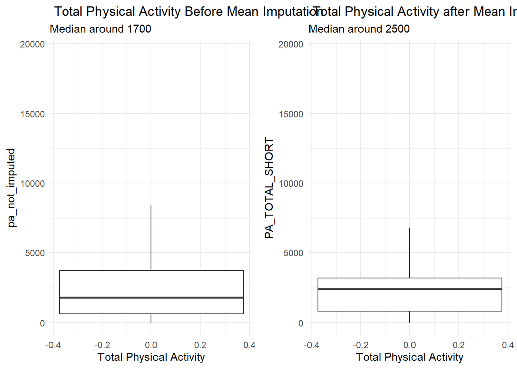

```r
plot_grid(Non_imputed_pa, imputed_pa)
```

We can see the median for the non imputed variable is around 1700, The median value from the imputed graph can not be determined explicitly with full certainty however, it is probably around 2500. Mean imputation can bias estimate from these observations.

# **MICE Imputation**

Numeric Variables are Imputed using Predictive Mean Matching (PMM) by default. This involves building a linear regression model on complete cases, predicting values for missing cases, and then drawing imputed values from observed cases with similar predicted values.

```r
data_mice <- mice(health_data, m = 5, maxit = 5) # imputing missing data for each variable in the dataset using MICE with 5  imputed datasets , and 5 control iterations.
data_mice_complete <- complete(data_mice, action = "long")

data_mice_complete %>%
  head() # Displaying first six(6) rows of the MICE imputed dataset
```

```
##          ID HS_GEN_HEALTH NUT_VEG_QTY NUT_FRUITS_QTY PA_TOTAL_SHORT
## 1 SYN_58621             3           3              1           3564
## 2 SYN_58622             4           0              0              0
## 3 SYN_58623             3           5              3           4998
## 4 SYN_58624             4           1              3            594
## 5 SYN_58625             3           2              3            231
## 6 SYN_58626             5           5              5           8559
##   DIS_ASTHMA_EVER DIS_DIAB_EVER .imp .id
## 1               0             0    1   1
## 2               0             0    1   2
## 3               2             2    1   3
## 4               0             0    1   4
## 5               1             2    1   5
## 6               2             2    1   6
```

```r
data_mice_complete %>%
  tail() # Displaying last six(6) rows of the MICE imputed dataset
```

```
##                   ID HS_GEN_HEALTH NUT_VEG_QTY NUT_FRUITS_QTY PA_TOTAL_SHORT
## 205930 SYN_586241182             4           5              2         7217.1
## 205931 SYN_586241183             4           1              1          819.0
## 205932 SYN_586241184             5           1              1          753.0
## 205933 SYN_586241185             3           2              1            0.0
## 205934 SYN_586241186             3           2              3         1859.5
## 205935 SYN_586241187             2           4              2         2133.0
##        DIS_ASTHMA_EVER DIS_DIAB_EVER .imp   .id
## 205930               0             0    5 41182
## 205931               0             0    5 41183
## 205932               0             0    5 41184
## 205933               0             0    5 41185
## 205934               0             0    5 41186
## 205935               0             1    5 41187
```

```r
data_mice$method
```

```
##              ID   HS_GEN_HEALTH     NUT_VEG_QTY  NUT_FRUITS_QTY  PA_TOTAL_SHORT
##              ""           "pmm"           "pmm"           "pmm"           "pmm"
## DIS_ASTHMA_EVER   DIS_DIAB_EVER
##           "pmm"           "pmm"
```

## Renaming of data_mice variables

I want to join the variables in data_mice_complete with health_data. However, they have the same columns name which may be confusing, so I want to rename the data_mice_complete variable.

```r
data_mice_complete <- data_mice_complete %>%
  rename(HS_GEN_HEALTH_imp = HS_GEN_HEALTH,
         NUT_VEG_QTY_imp = NUT_VEG_QTY,
         NUT_FRUITS_QTY_imp = NUT_FRUITS_QTY,
         PA_TOTAL_SHORT_imp = PA_TOTAL_SHORT,
         DIS_ASTHMA_EVER_imp = DIS_ASTHMA_EVER,
         DIS_DIAB_EVER_imp = DIS_DIAB_EVER)

data_mice_complete %>%
  head()
```

```
##          ID HS_GEN_HEALTH_imp NUT_VEG_QTY_imp NUT_FRUITS_QTY_imp
## 1 SYN_58621                 3               3                  1
## 2 SYN_58622                 4               0                  0
## 3 SYN_58623                 3               5                  3
## 4 SYN_58624                 4               1                  3
## 5 SYN_58625                 3               2                  3
## 6 SYN_58626                 5               5                  5
##   PA_TOTAL_SHORT_imp DIS_ASTHMA_EVER_imp DIS_DIAB_EVER_imp .imp .id
## 1               3564                   0                 0    1   1
## 2                  0                   0                 0    1   2
## 3               4998                   2                 2    1   3
## 4                594                   0                 0    1   4
## 5                231                   1                 2    1   5
## 6               8559                   2                 2    1   6
```

## Joining the two datasets

```r
health_data_c <- full_join( health_data, data_mice_complete, by = join_by("ID"))   # This code merges the original dataset health_data with a mice-imputed dataset data_mice_complete using a full join on the ID column. The resulting health_data_c contains both the original and imputed values, allowing side-by-side comparison of variables before and after imputation.

health_data_c %>%
  head()
```

```
## # A tibble: 6 × 15
##   ID     HS_GEN_HEALTH NUT_VEG_QTY NUT_FRUITS_QTY PA_TOTAL_SHORT DIS_ASTHMA_EVER
##   <chr>          <dbl>       <dbl>          <dbl>          <dbl>           <dbl>
## 1 SYN_5…             3           3              1           3564               0
## 2 SYN_5…             3           3              1           3564               0
## 3 SYN_5…             3           3              1           3564               0
## 4 SYN_5…             3           3              1           3564               0
## 5 SYN_5…             3           3              1           3564               0
## 6 SYN_5…             4           0              0              0               0
## # ℹ 9 more variables: DIS_DIAB_EVER <dbl>, HS_GEN_HEALTH_imp <dbl>,
## #   NUT_VEG_QTY_imp <dbl>, NUT_FRUITS_QTY_imp <dbl>, PA_TOTAL_SHORT_imp <dbl>,
## #   DIS_ASTHMA_EVER_imp <dbl>, DIS_DIAB_EVER_imp <dbl>, .imp <int>, .id <int>
```

The data_mice has been full join to the health_data to a common variable - health_data_c. This is to allow for comparison of imputed and not imputed variables

## Data Visualization

### Density plot of PA_TOTAL_SHORT

```r
summary(health_data_c$PA_TOTAL_SHORT)
```

```
##    Min. 1st Qu.  Median    Mean 3rd Qu.    Max.    NA's
##       0     600    1782    2574    3732   19278   33815
```

```r
summary(health_data_c$PA_TOTAL_SHORT_imp)
```

```
##    Min. 1st Qu.  Median    Mean 3rd Qu.    Max.
##       0     594    1786    2585    3756   19278
```

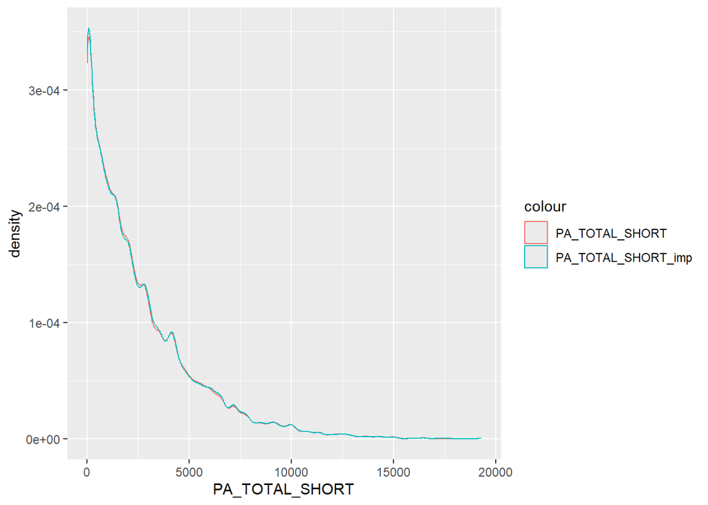

```r
density_imp <- ggplot(health_data_c) +
                geom_density(aes(PA_TOTAL_SHORT, colour= "PA_TOTAL_SHORT")) +
                geom_density(aes(PA_TOTAL_SHORT_imp, colour= "PA_TOTAL_SHORT_imp"))
plot(density_imp)
```

A similar distribution can be seen for Pa-total imputed and pa_total_not imputed.

### Density plot of PA_TOTAL_SHORT by .imp

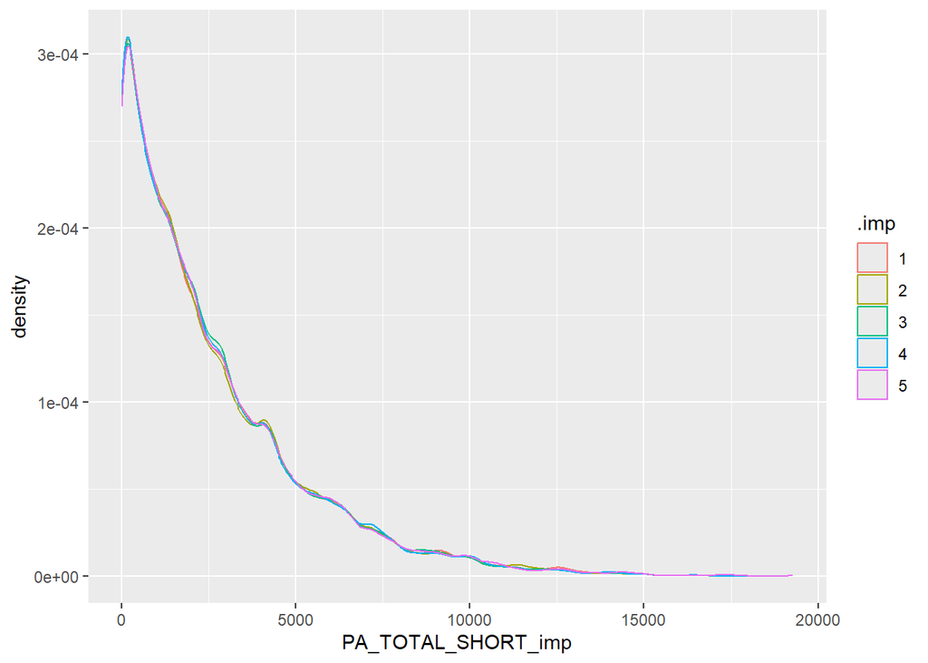

```r
density_m_5 <- health_data_c %>%
  mutate(.imp = as.factor(.imp)) %>%   # Converting .imp to a factor
  ggplot(aes(x = PA_TOTAL_SHORT_imp, colour = .imp)) +
                geom_density()
plot(density_m_5)
```

A similar distribution was seen for each imputation made using MICE.

The two main dataset that I am using are the health_data which contains missing data and data_mice_complete which contains imputed values.Now this datasets have been joined to health_data_c.

Let me summarize all the datasets before I proceed.

## Descriptive summary of Dataset before and after MICE imputation

### Summary of dataset befoe MICE imputation

```r
health_data %>%
  summary()
```

```
##       ID            HS_GEN_HEALTH    NUT_VEG_QTY     NUT_FRUITS_QTY
##  Length:41187       Min.   :1.000   Min.   : 0.000   Min.   : 0.000
##  Class :character   1st Qu.:3.000   1st Qu.: 2.000   1st Qu.: 1.000
##  Mode  :character   Median :4.000   Median : 2.000   Median : 2.000
##                     Mean   :3.638   Mean   : 2.672   Mean   : 2.132
##                     3rd Qu.:4.000   3rd Qu.: 3.000   3rd Qu.: 3.000
##                     Max.   :5.000   Max.   :35.000   Max.   :25.000
##                     NA's   :672     NA's   :2549     NA's   :2426
##  PA_TOTAL_SHORT  DIS_ASTHMA_EVER  DIS_DIAB_EVER
##  Min.   :    0   Min.   :0.0000   Min.   :0.0000
##  1st Qu.:  600   1st Qu.:0.0000   1st Qu.:0.0000
##  Median : 1782   Median :0.0000   Median :0.0000
##  Mean   : 2574   Mean   :0.2039   Mean   :0.1402
##  3rd Qu.: 3732   3rd Qu.:0.0000   3rd Qu.:0.0000
##  Max.   :19278   Max.   :2.0000   Max.   :2.0000
##  NA's   :6763    NA's   :1228     NA's   :1340
```

we can see NA’s across each variable. This shows missing data point(s) is not imputed.

### Summary of Dataset after MICE Imputation

```r
health_data_imputed <- miss_var_summary(data_mice_complete)
health_data_imputed
```

```
## # A tibble: 9 × 3
##   variable            n_miss pct_miss
##   <chr>                <int>    <num>
## 1 ID                       0        0
## 2 HS_GEN_HEALTH_imp        0        0
## 3 NUT_VEG_QTY_imp          0        0
## 4 NUT_FRUITS_QTY_imp       0        0
## 5 PA_TOTAL_SHORT_imp       0        0
## 6 DIS_ASTHMA_EVER_imp      0        0
## 7 DIS_DIAB_EVER_imp        0        0
## 8 .imp                     0        0
## 9 .id                      0        0
```

```r
data_mice_complete %>%
  summary()
```

```
##       ID            HS_GEN_HEALTH_imp NUT_VEG_QTY_imp  NUT_FRUITS_QTY_imp
##  Length:205935      Min.   :1.000     Min.   : 0.000   Min.   : 0.000
##  Class :character   1st Qu.:3.000     1st Qu.: 2.000   1st Qu.: 1.000
##  Mode  :character   Median :4.000     Median : 2.000   Median : 2.000
##                     Mean   :3.636     Mean   : 2.666   Mean   : 2.131
##                     3rd Qu.:4.000     3rd Qu.: 3.000   3rd Qu.: 3.000
##                     Max.   :5.000     Max.   :35.000   Max.   :25.000
##  PA_TOTAL_SHORT_imp DIS_ASTHMA_EVER_imp DIS_DIAB_EVER_imp      .imp
##  Min.   :    0      Min.   :0.0000      Min.   :0.0000    Min.   :1
##  1st Qu.:  594      1st Qu.:0.0000      1st Qu.:0.0000    1st Qu.:2
##  Median : 1786      Median :0.0000      Median :0.0000    Median :3
##  Mean   : 2585      Mean   :0.2042      Mean   :0.1452    Mean   :3
##  3rd Qu.: 3756      3rd Qu.:0.0000      3rd Qu.:0.0000    3rd Qu.:4
##  Max.   :19278      Max.   :2.0000      Max.   :2.0000    Max.   :5
##       .id
##  Min.   :    1
##  1st Qu.:10297
##  Median :20594
##  Mean   :20594
##  3rd Qu.:30891
##  Max.   :41187
```

It can be seen that there is no missing data in the health_imputed dataset. This means the data points were correctly imputed using MICE.

### Boxplot of PA_TOTAL_SHORT before MICE_imputation

```r
plot_before_mice <- health_data %>%
  ggplot(aes(PA_TOTAL_SHORT))+
  geom_boxplot()+
  labs(title = "Boxplot of Total physcial activity before MICE imputation",
       subtitle = "Median can be seen around around 1700")+
  coord_flip()  # This code creates a horizontal boxplot of PA_TOTAL_SHORT values from the original health_data dataset before MICE imputation. It uses geom_boxplot() to visualize the distribution, central tendency (median), and potential outliers. The plot includes a descriptive title and subtitle.
```

### Boxplot of PA_TOTAL_SHORT after MICE_imputation

```r
plot_after_mice <- pa_short_plot <- data_mice_complete %>%
  ggplot(aes(PA_TOTAL_SHORT_imp))+
  geom_boxplot()+
  labs(title = "Boxplot of Total physcial activity after MICE imputation",
       subtitle = "Median can be seen around around 1700")+
  coord_flip() # This code creates a horizontal boxplot of PA_TOTAL_SHORT values from the original health_data dataset after MICE imputation. It uses geom_boxplot() to visualize the distribution, central tendency (median), and potential outliers. The plot includes a descriptive title and subtitle.
```

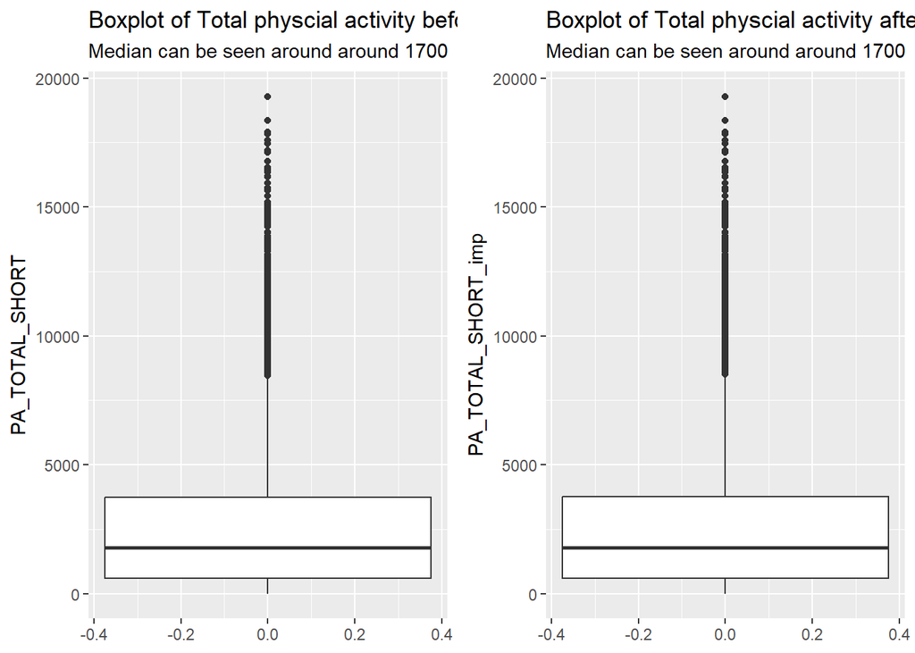

```r
plot_grid(plot_before_mice, plot_after_mice)
```

We can see the median value for physical activity before and after mice imputation are close ~ 1700. Comparing to mean_imputation( which had a median of ~ 2500). we can say mean_imputation can over or in other situations underestimate a sample parameter.

# **Using KNN Methods**

## Overview of Dataset without imputed missing values

```r
health_data %>%
  head() # displaying the first six(6) rows in the raw dataset(non imputed)
```

```
## # A tibble: 6 × 7
##   ID     HS_GEN_HEALTH NUT_VEG_QTY NUT_FRUITS_QTY PA_TOTAL_SHORT DIS_ASTHMA_EVER
##   <chr>          <dbl>       <dbl>          <dbl>          <dbl>           <dbl>
## 1 SYN_5…             3           3              1           3564               0
## 2 SYN_5…             4           0              0              0               0
## 3 SYN_5…             3           5              3             NA               2
## 4 SYN_5…             4           1              3            594               0
## 5 SYN_5…             3           2              3             NA               1
## 6 SYN_5…             5           5              5             NA               2
## # ℹ 1 more variable: DIS_DIAB_EVER <dbl>
```

```r
health_data %>%
  summarise_all(~sum(is.na(.)))  # Displaying missing values in each column
```

```
## # A tibble: 1 × 7
##      ID HS_GEN_HEALTH NUT_VEG_QTY NUT_FRUITS_QTY PA_TOTAL_SHORT DIS_ASTHMA_EVER
##   <int>         <int>       <int>          <int>          <int>           <int>
## 1     0           672        2549           2426           6763            1228
## # ℹ 1 more variable: DIS_DIAB_EVER <int>
```

## KNN Imputation using “VIM”

```r
knn_imputed <- VIM::kNN(health_data, k = 3) # This code applies K-Nearest Neighbors (KNN) imputation using the VIM::kNN() function to fill missing values in the health_data dataset, using k=3 nearest neighbors. The method replaces missing entries with values from the most similar observations based on other variable patterns. The result, knn_imputed, contains both imputed values and indicators of where imputation occurred.

knn_imputed %>%
  head()
```

```
##          ID HS_GEN_HEALTH NUT_VEG_QTY NUT_FRUITS_QTY PA_TOTAL_SHORT
## 1 SYN_58621             3           3              1           3564
## 2 SYN_58622             4           0              0              0
## 3 SYN_58623             3           5              3           2628
## 4 SYN_58624             4           1              3            594
## 5 SYN_58625             3           2              3            297
## 6 SYN_58626             5           5              5           2628
##   DIS_ASTHMA_EVER DIS_DIAB_EVER ID_imp HS_GEN_HEALTH_imp NUT_VEG_QTY_imp
## 1               0             0  FALSE             FALSE           FALSE
## 2               0             0  FALSE             FALSE           FALSE
## 3               2             2  FALSE             FALSE           FALSE
## 4               0             0  FALSE             FALSE           FALSE
## 5               1             2  FALSE             FALSE           FALSE
## 6               2             2  FALSE             FALSE           FALSE
##   NUT_FRUITS_QTY_imp PA_TOTAL_SHORT_imp DIS_ASTHMA_EVER_imp DIS_DIAB_EVER_imp
## 1              FALSE              FALSE               FALSE             FALSE
## 2              FALSE              FALSE               FALSE             FALSE
## 3              FALSE               TRUE               FALSE             FALSE
## 4              FALSE              FALSE               FALSE              TRUE
## 5              FALSE               TRUE               FALSE             FALSE
## 6              FALSE               TRUE               FALSE             FALSE
```

### Summary of Dataset after KNN Imputation

```r
knn_imputed %>%
  summary() # This displays the summary of the variables after KNN imputation using K = 3 neighbors.
```

```
##       ID            HS_GEN_HEALTH    NUT_VEG_QTY     NUT_FRUITS_QTY
##  Length:41187       Min.   :1.000   Min.   : 0.000   Min.   : 0.000
##  Class :character   1st Qu.:3.000   1st Qu.: 2.000   1st Qu.: 1.000
##  Mode  :character   Median :4.000   Median : 2.000   Median : 2.000
##                     Mean   :3.625   Mean   : 2.647   Mean   : 2.127
##                     3rd Qu.:4.000   3rd Qu.: 3.000   3rd Qu.: 3.000
##                     Max.   :5.000   Max.   :35.000   Max.   :25.000
##  PA_TOTAL_SHORT  DIS_ASTHMA_EVER  DIS_DIAB_EVER      ID_imp
##  Min.   :    0   Min.   :0.0000   Min.   :0.0000   Mode :logical
##  1st Qu.:  690   1st Qu.:0.0000   1st Qu.:0.0000   FALSE:41187
##  Median : 1818   Median :0.0000   Median :0.0000
##  Mean   : 2505   Mean   :0.2108   Mean   :0.1401
##  3rd Qu.: 3564   3rd Qu.:0.0000   3rd Qu.:0.0000
##  Max.   :19278   Max.   :2.0000   Max.   :2.0000
##  HS_GEN_HEALTH_imp NUT_VEG_QTY_imp NUT_FRUITS_QTY_imp PA_TOTAL_SHORT_imp
##  Mode :logical     Mode :logical   Mode :logical      Mode :logical
##  FALSE:40515       FALSE:38638     FALSE:38761        FALSE:34424
##  TRUE :672         TRUE :2549      TRUE :2426         TRUE :6763
##
##
##
##  DIS_ASTHMA_EVER_imp DIS_DIAB_EVER_imp
##  Mode :logical       Mode :logical
##  FALSE:39959         FALSE:39847
##  TRUE :1228          TRUE :1340
##
##
##
```

### Boxplot of PA_TOTAL_SHORT before KNN_imputation

```r
pa_short_plot <- health_data %>%
  ggplot(aes(PA_TOTAL_SHORT))+
  geom_boxplot()+
  labs(title = "Boxplot of Total physcial activity before KNN imputation",
       subtitle = "Median can be seen around around 1700")+
  coord_flip()  # This code creates a horizontal boxplot of PA_TOTAL_SHORT from the original health_data before applying KNN imputation. It uses geom_boxplot() to visualize the data’s spread, central tendency (median), and potential outliers, with a clear title and subtitle for interpretation.
```

### Boxplot of PA_TOTAL_SHORT after KNN _imputation

```r
pa_short_plot_knn <-ggplot(knn_imputed, aes(PA_TOTAL_SHORT))+
  geom_boxplot()+
  coord_flip()+
  labs(title = "Boxplot of PA_TOTAL_SHORT after KNN Imputation using VIM",
       subtitle = "Median value around 1700 min") # This code creates a horizontal boxplot of PA_TOTAL_SHORT from the original health_data afterapplying KNN imputation. It uses geom_boxplot() to visualize the data’s spread, central tendency (median), and potential outliers, with a clear title and subtitle for interpretation.
```

### BOxplot of Pa_total_short comparison

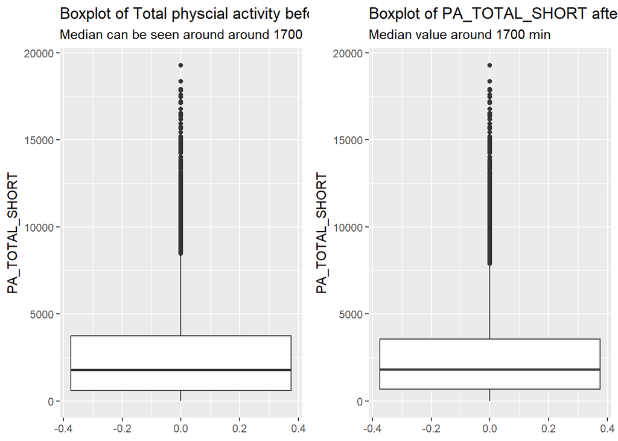

```r
plot_grid(pa_short_plot,pa_short_plot_knn)
```

It can be observed that the distribution of the variable mean did not change significantly after KNN Imputation

# **Regression Model**

I want to use simple regression to further show or display how the various types of data imputation method used in this porject affects or bias an association.

I will build 4 regression models for: 1. the raw dataset with missing values, 2. the mean imputed dataset 3. the MICE imputed dataset 4. KNN dataset

## Regression model using non_imputed dataset

```r
pa_fruit_model <- lm (PA_TOTAL_SHORT ~ NUT_FRUITS_QTY, data = health_data )  # This code fits a simple linear regression model using lm() to predict PA_TOTAL_SHORT (total physical activity) based on NUT_FRUITS_QTY (daily fruit intake).

pa_fruit_model %>%
  summary()  # The summary() function outputs model coefficients, R-squared, and statistical significance for the relationship.
```

```
##
## Call:
## lm(formula = PA_TOTAL_SHORT ~ NUT_FRUITS_QTY, data = health_data)
##
## Residuals:
##     Min      1Q  Median      3Q     Max
## -4119.2 -1929.6  -795.3  1153.2 16902.9
##
## Coefficients:
##                Estimate Std. Error t value Pr(>|t|)
## (Intercept)     2181.29      26.48   82.38   <2e-16 ***
## NUT_FRUITS_QTY   193.79      10.47   18.51   <2e-16 ***
## ---
## Signif. codes:  0 '***' 0.001 '**' 0.01 '*' 0.05 '.' 0.1 ' ' 1
##
## Residual standard error: 2646 on 33492 degrees of freedom
##   (7693 observations deleted due to missingness)
## Multiple R-squared:  0.01012,    Adjusted R-squared:  0.01009
## F-statistic: 342.5 on 1 and 33492 DF,  p-value: < 2.2e-16
```

We can see that the model with missing data showed a significant association between fruit quantity and physical activity total with a pvalue less than 0.001. A unit increase in fruit quantity, increases physical activity by 193.79 minutes.

## Regression model using mean imputed dataset

```r
pa_fruit_model <- lm (PA_TOTAL_SHORT ~ NUT_FRUITS_QTY, data = data_shadow ) # This code fits a linear regression model on the mean_imputed dataset from fruit intake (NUT_FRUITS_QTY).

pa_fruit_model %>%
  summary()
```

```
##
## Call:
## lm(formula = PA_TOTAL_SHORT ~ NUT_FRUITS_QTY, data = data_shadow)
##
## Residuals:
##     Min      1Q  Median      3Q     Max
## -3844.3 -1776.4  -395.9   711.1 16869.1
##
## Coefficients:
##                Estimate Std. Error t value Pr(>|t|)
## (Intercept)    2249.448     22.619   99.45   <2e-16 ***
## NUT_FRUITS_QTY  159.483      8.842   18.04   <2e-16 ***
## ---
## Signif. codes:  0 '***' 0.001 '**' 0.01 '*' 0.05 '.' 0.1 ' ' 1
##
## Residual standard error: 2462 on 38759 degrees of freedom
##   (2426 observations deleted due to missingness)
## Multiple R-squared:  0.008325,   Adjusted R-squared:  0.008299
## F-statistic: 325.4 on 1 and 38759 DF,  p-value: < 2.2e-16
```

We can see that with a unit increase in NUT_FRUITS_QTY, Physical activity increases by 159.5 minutes which is statistically significant(p_value<0.001)